# Wrangling III

In this tutorial, we'll round out our focus on data wrangling by looking

- handling duplicate values
- data transformations

## Preliminaries

As usual, we'll load some libraries we'll be likely to use.

```python
import numpy as np
import pandas as pd
import matplotlib.pyplot as plt
import seaborn as sns
```

Now we'll get set up to work by

- loading the cancer data and cleaning it up (as before)
- trim out some columns so we can look at the data frame more easily
- shorten up some of the column names to save ourselves some typing

Let's reuse our function to do the loading and cleaning.

```python
def bcd_load_clean():
    bcd = pd.read_csv('./data/breast_cancer_data.csv')
    bcd['patient_id'] = bcd['patient_id'].astype('string')
    bcd['doctor_name'] = bcd['doctor_name'].str.split().str[1]
    bcd['bare_nuclei'] = bcd['bare_nuclei'].replace('?', '')
    bcd['bare_nuclei'] = pd.to_numeric(bcd['bare_nuclei'])

    return bcd
```

```python
bcd = bcd_load_clean()
```

Make a little version with just two numeric columns to play with.

```python
bcd2 = bcd[['patient_id', 'clump_thickness', 'bland_chromatin', 'class']].copy()
```

Let's give the columns shorter names to save some typing.

```python
bcd2 = bcd2.rename(columns={'clump_thickness': 'thick',
                            'bland_chromatin': 'chrom',
                            'patient_id': 'id'})
```

## Duplicate entries

As we have already seen, datasets can contain strange things that we have to overcome prior to analysis. One of the most common issues in a dataset are duplicate entries. These are common with large datasets that have been transcribed by humans at some point. Humands get bored, lose their place, etc.

Let's look at the shape of our cancer data frame (remember data frames have a `shape` attribute).

```python
bcd2.shape
```

```
(699, 4)
```

Now let's look at the number of unique entries using the `nunique()` data frame method; this will return the number of distinct values in each column.

```python
bcd2.nunique()
```

```
id       645
thick     10
chrom     10
class      2
dtype: int64
```

So we can see that, while there are 699 observations in our data, there are only 645 unique patient ids. This tells us that several patients have multiple entries. These could be from patients making multiple visits to the doctor, or they could be a mistakes, or some combination thereof.

We can find out which rows – which entire observations – are identical with the `duplicated()` method.

```python
bcd2.duplicated()
```

```
0      False
1      False
2      False
3      False
4      False
       ...
694    False
695    False
696    False
697    False
698     True
Length: 699, dtype: bool
```

That's not terribly helpful by itself, but...

In the cell below, count the number of duplicated rows (remember a True is a 1).

```python
bcd2.duplicated().sum()
```

```
12
```

We can also use the output of `.duplicated()` to do logical indexing to see the observations that have duplicates. Do that in the cell below.

```python
bcd2[bcd2.duplicated()]
```

|  | id | thick | chrom | class |
| --- | --- | --- | --- | --- |
| 208 | 1218860 | 1.0 | 3.0 | benign |
| 253 | 1100524 | 6.0 | 7.0 | malignant |
| 254 | 1116116 | 9.0 | 3.0 | malignant |
| 258 | 1198641 | 3.0 | 3.0 | benign |
| 272 | 320675 | 3.0 | 7.0 | malignant |
| 322 | 733639 | 3.0 | 3.0 | benign |
| 338 | 704097 | 1.0 | 2.0 | benign |
| 443 | 734111 | 1.0 | 1.0 | benign |
| 561 | 1321942 | 5.0 | 3.0 | benign |
| 684 | 466906 | 1.0 | 1.0 | benign |
| 690 | 654546 | 1.0 | 1.0 | benign |
| 698 | 897471 | 4.0 | 10.0 | malignant |

This is promising but, if we look at what is listed, we don't actually see any duplicates. So what is `duplicates()` doing?

Use the cell below to get help on `duplicated()` using `help()` or `?`.

```python
help(bcd2.duplicated())
```

[output not shown]

[output cut: 12500 more lines]

[output not shown]

Go ahead and do that in the cell below.

```python
bcd2.duplicated(keep=False)
```

```
0      False
1      False
2      False
3      False
4      False
       ...
694    False
695    False
696    False
697     True
698     True
Length: 699, dtype: bool
```

Hm. That's somewhat helpful. If we look near the bottom, we see that the last 5 or so duplicates occur in successive rows, perhaps indicating a data entry mistake. Perhaps looking at the data sorted by patient ID would be more helpful.

In the cell below, use the the `.sort_values()` method to look at our duplicates sorted by ID.

```python
bcd2[bcd2.duplicated(keep=False)].sort_values(by='id')
```

|  | id | thick | chrom | class |
| --- | --- | --- | --- | --- |
| 42 | 1100524 | 6.0 | 7.0 | malignant |
| 253 | 1100524 | 6.0 | 7.0 | malignant |
| 62 | 1116116 | 9.0 | 3.0 | malignant |
| 254 | 1116116 | 9.0 | 3.0 | malignant |
| 168 | 1198641 | 3.0 | 3.0 | benign |
| 258 | 1198641 | 3.0 | 3.0 | benign |
| 207 | 1218860 | 1.0 | 3.0 | benign |
| 208 | 1218860 | 1.0 | 3.0 | benign |
| 561 | 1321942 | 5.0 | 3.0 | benign |
| 560 | 1321942 | 5.0 | 3.0 | benign |
| 272 | 320675 | 3.0 | 7.0 | malignant |
| 267 | 320675 | 3.0 | 7.0 | malignant |
| 684 | 466906 | 1.0 | 1.0 | benign |
| 683 | 466906 | 1.0 | 1.0 | benign |
| 690 | 654546 | 1.0 | 1.0 | benign |
| 689 | 654546 | 1.0 | 1.0 | benign |
| 314 | 704097 | 1.0 | 2.0 | benign |
| 338 | 704097 | 1.0 | 2.0 | benign |
| 321 | 733639 | 3.0 | 3.0 | benign |
| 322 | 733639 | 3.0 | 3.0 | benign |
| 442 | 734111 | 1.0 | 1.0 | benign |
| 443 | 734111 | 1.0 | 1.0 | benign |
| 697 | 897471 | 4.0 | 10.0 | malignant |
| 698 | 897471 | 4.0 | 10.0 | malignant |

So most of the duplicates occur in adjacent rows, but others do not. Perhaps we should check and see if the same patients occur multiple times with different measurements, indicating multiple visits to the doctor.

Use the cell below and the `subset` argument to `duplicated()` to look at multiple entries for any patients that have them.

```python
bcd2[bcd2.duplicated(subset='id', keep=False)].sort_values(by='id')
```

|  | id | thick | chrom | class |
| --- | --- | --- | --- | --- |
| 4 | 1017023 | 4.0 | 3.0 | benign |
| 252 | 1017023 | 6.0 | 3.0 | benign |
| 8 | 1033078 | 2.0 | 1.0 | benign |
| 9 | 1033078 | 4.0 | 2.0 | benign |
| 618 | 1061990 | 4.0 | 2.0 | benign |
| ... | ... | ... | ... | ... |
| 527 | 798429 | 4.0 | 3.0 | benign |
| 344 | 822829 | 7.0 | 9.0 | malignant |
| 612 | 822829 | 8.0 | 10.0 | malignant |
| 697 | 897471 | 4.0 | 10.0 | malignant |
| 698 | 897471 | 4.0 | 10.0 | malignant |

100 rows × 4 columns

Now, in the cell below, do the same thing but sort the output by patient ID.

```python
bcd2[bcd2.duplicated(subset='id', keep=False)].sort_values(by='id')
```

|  | id | thick | chrom | class |
| --- | --- | --- | --- | --- |
| 4 | 1017023 | 4.0 | 3.0 | benign |
| 252 | 1017023 | 6.0 | 3.0 | benign |
| 8 | 1033078 | 2.0 | 1.0 | benign |
| 9 | 1033078 | 4.0 | 2.0 | benign |
| 618 | 1061990 | 4.0 | 2.0 | benign |
| ... | ... | ... | ... | ... |
| 527 | 798429 | 4.0 | 3.0 | benign |
| 344 | 822829 | 7.0 | 9.0 | malignant |
| 612 | 822829 | 8.0 | 10.0 | malignant |
| 697 | 897471 | 4.0 | 10.0 | malignant |
| 698 | 897471 | 4.0 | 10.0 | malignant |

100 rows × 4 columns

So it looks like patients do come in multiple times and the values can change between visits.

We can look at repeat patient's number of visits directly if we want. We'll take advantage of the fact that the `.size` of a `groupby()` object returns the number of rows for each group.

```python
repeat_patients = bcd2.groupby('id').size().sort_values(ascending =False)
```

```python
repeat_patients
```

```
id
1182404    6
1276091    5
1198641    3
1299596    2
1158247    2
          ..
1200892    1
1200952    1
1201834    1
1201870    1
95719      1
Length: 645, dtype: int64
```

So one patient came in 6 times.

Use the cell below look at the data for the patient with 6 visits.

```python
bcd2[bcd2['id'] == '1182404']
```

|  | id | thick | chrom | class |
| --- | --- | --- | --- | --- |
| 136 | 1182404 | 4.0 | 2.0 | benign |
| 256 | 1182404 | 3.0 | 1.0 | benign |
| 257 | 1182404 | 3.0 | 2.0 | benign |
| 265 | 1182404 | 5.0 | 3.0 | benign |
| 448 | 1182404 | 1.0 | 1.0 | benign |
| 497 | 1182404 | 4.0 | 1.0 | benign |

So it appears that some patients have multiple legitimate entries in the data frame.

If you were put in charge of analyzing these data, what would you do with duplicate observations in this data frame, and why?

Duplicates with the exact same measurements for all values would be discarded, but it would still implement values for repeat visits.

## Transforming data

Sometimes we wish to apply a transform to data by pushing each data value through some function. Common transformations are unit conversions (miles to kilometers, for example), log or power transformations, and normalizing data (for example, converting data to z-scores).

### Transforming data with a built-in function

Consider the following data...

```python
df = pd.DataFrame({'x': range(6),
                   'y': [0.1, 0.9, 4.2, 8.7, 15.9, 26]})
```

```python
df
```

|  | x | y |
| --- | --- | --- |
| 0 | 0 | 0.1 |
| 1 | 1 | 0.9 |
| 2 | 2 | 4.2 |
| 3 | 3 | 8.7 |
| 4 | 4 | 15.9 |
| 5 | 5 | 26.0 |

Plot the data (y vs. x) (seaborn's `relplot()` is handy).

```python
%matplotlib inline
```

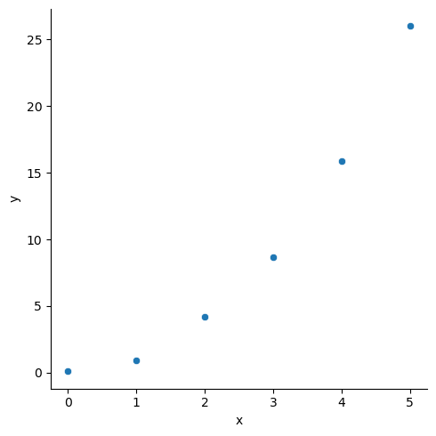

```python
# plot y vs. x
sns.relplot(data=df, x='x',y='y')
```

These data look non-linear, like they are following a power law. If that's true, we should get a straight line if we plot the log of the values against one another. In order to get these values, we will use the `transform()` method to convert the values into their logs.

```python
df_trans = df.copy()
df_trans['y'] = df['y'].transform(np.log10)
df_trans['x'] = df['x'].transform(np.log10)
```

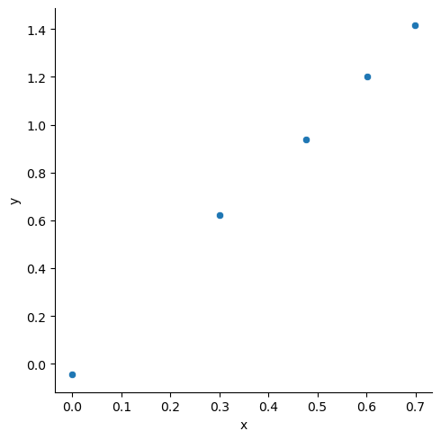

```python
# plot new y vs. new x
sns.relplot(data=df_trans, x='x',y='y')
```

Sure enough. The slope of the line should tell us the exponent of the power law, and it looks to be about 2. If that's the case, then transforming the original y-values with a square-root function should also produce a straight line.

In the cells below, use `transform()` to get the square root of the original y values, and plot them against the x values.

```python
# get sqrts
df['y_sqrt'] = df['y'].transform(np.sqrt)
```

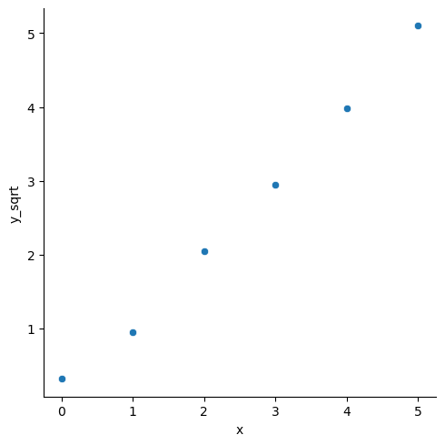

```python
#plot
sns.relplot(data=df,x='x',y='y_sqrt')
```

We could also transform our cancer data. In the cell below, create a new data frame in which the numeric values are the natural log of the original values.

```python
# compute log vals
numeric_cols = bcd2.select_dtypes(include=np.number).columns
```

```python
bcd_log = bcd2[numeric_cols].transform(np.log)

bcd_log.head()
```

|  | thick | chrom |
| --- | --- | --- |
| 0 | 1.609438 | 1.098612 |
| 1 | 1.609438 | 1.098612 |
| 2 | 1.098612 | 1.098612 |
| 3 | 1.791759 | 1.098612 |
| 4 | 1.386294 | 1.098612 |

### Applying a custom function to data

A great thing about `transform()` (and some other data frame methods) is you can use your own fuctions, not just built in ones.

For `transform()`, the only requirement is that your function

- be able to take a data frame as input
- produce output the same size as the input, or
- produce a single value

Here's a function to "center" data by subtracting the mean from each value.

```python
def center_data(grp):
    grp_mean = grp.mean(numeric_only = True)

    grp = (grp - grp_mean)

    return grp
```

In the cell below, use our new function to create a new version of our cancer data frame with the mean removed from each group of data. The `.transform()` method works column-by-column, so you don't need to worry about grouping the data.

```python
bcd_centered = bcd2[numeric_cols].transform(center_data)
bcd_centered
```

|  | thick | chrom |
| --- | --- | --- |
| 0 | 0.583095 | -0.447482 |
| 1 | 0.583095 | -0.447482 |
| 2 | -1.416905 | -0.447482 |
| 3 | 1.583095 | -0.447482 |
| 4 | -0.416905 | -0.447482 |
| ... | ... | ... |
| 694 | -1.416905 | -2.447482 |
| 695 | -2.416905 | -2.447482 |
| 696 | 0.583095 | 4.552518 |
| 697 | -0.416905 | 6.552518 |
| 698 | -0.416905 | 6.552518 |

699 rows × 2 columns

Confirm this worked by computing the mean for each column of your transformed data.

```python
bcd_centered[['thick', 'chrom']].mean()
```

```
thick    4.071878e-17
chrom    0.000000e+00
dtype: float64
```

In the cells below, write a function to convert the cancer data to z-scores, and use your new function to convert the numeric columns of our cancer data frame.

```python
# my z-score function!
def z_score(grp):
    grp_mean = grp.mean(numeric_only=True)
    grp_std = grp.std(numeric_only=True)

    grp_z = (grp - grp_mean) / grp_std
    return grp_z
```

```python
# run transform() with my function
bcd_z = bcd2[numeric_cols].transform(z_score)
```

```python
# look at the transformed data
bcd_z
```

|  | thick | chrom |
| --- | --- | --- |
| 0 | 0.206942 | -0.183305 |
| 1 | 0.206942 | -0.183305 |
| 2 | -0.502864 | -0.183305 |
| 3 | 0.561845 | -0.183305 |
| 4 | -0.147961 | -0.183305 |
| ... | ... | ... |
| 694 | -0.502864 | -1.002577 |
| 695 | -0.857766 | -1.002577 |
| 696 | 0.206942 | 1.864876 |
| 697 | -0.147961 | 2.684148 |
| 698 | -0.147961 | 2.684148 |

699 rows × 2 columns

```python
print("Means")
print(bcd_z[['thick', 'chrom']].mean())

print("\nStandard Deviation")
print(bcd_z[['thick', 'chrom']].std())
```

```
Means
thick    3.053909e-17
chrom    6.134182e-17
dtype: float64

Standard Deviation
thick    1.0
chrom    1.0
dtype: float64
```

#### lambda functions

Lambda functions, also know as anonymous functions, are short, one-off functions that are often used in situation in which ***all*** you need the function for is get passed to a method such as `transform()`

While the structure of a normal function is:

```python
def func_name(input_arg) :
    caluculations
    ret_val = more calculations

    return ret_val
```

[output not shown]

The structure of a lambda function is:

```python
lambda input_arg : calculation of ret_val
```

Here's how we would compute z-scores using a lambda function:

```python
trans_data = bcd2[['thick', 'chrom']].transform(
    lambda col_vals: (col_vals - col_vals.mean()) / col_vals.std()
)
```

Note that the entire lambda function is the one and only input to `transform()`.

In the cell below, confirm that the lambda function method worked.

```python
print("Means")
print(trans_data[['thick', 'chrom']].mean())

print("\nStandard Deviation")
print(trans_data[['thick', 'chrom']].std())
```

```
Means
thick    3.053909e-17
chrom    6.134182e-17
dtype: float64

Standard Deviation
thick    1.0
chrom    1.0
dtype: float64
```

For very simple transformations, using a lambda function makes a lot of sense. For more complicated transformations, we'd probably want to just create a regular function, or the code could become unreadable.

How complicated is too complicated? That's up to you, but anything more complicated than applying an offset and a scale factor (like computing a z-score), probably deserves its own function.

In the cell below, transform the numeric cancer data so the values range from 0 to 1 using a lambda function. You can assume that the maximum value is 10 and the minimum value is 1.

```python
bcd_scaled = bcd2[numeric_cols].transform(lambda x: (x - 1) / (10 - 1))
bcd_scaled
```

|  | thick | chrom |
| --- | --- | --- |
| 0 | 0.444444 | 0.222222 |
| 1 | 0.444444 | 0.222222 |
| 2 | 0.222222 | 0.222222 |
| 3 | 0.555556 | 0.222222 |
| 4 | 0.333333 | 0.222222 |
| ... | ... | ... |
| 694 | 0.222222 | 0.000000 |
| 695 | 0.111111 | 0.000000 |
| 696 | 0.444444 | 0.777778 |
| 697 | 0.333333 | 1.000000 |
| 698 | 0.333333 | 1.000000 |

699 rows × 2 columns

In the cell below, us a regular function to rescale the values from 0 to 1. In this case, however, do not assume you know the minimum and maximum values ahead of time.

```python
def rescale_0_1(col):
    col_min = col.min()
    col_max = col.max()

    return (col - col_min) / (col_max - col_min)
```

```python
bcd_rescaled = bcd2[numeric_cols].transform(rescale_0_1)
bcd_rescaled
```

|  | thick | chrom |
| --- | --- | --- |
| 0 | 0.444444 | 0.222222 |
| 1 | 0.444444 | 0.222222 |
| 2 | 0.222222 | 0.222222 |
| 3 | 0.555556 | 0.222222 |
| 4 | 0.333333 | 0.222222 |
| ... | ... | ... |
| 694 | 0.222222 | 0.000000 |
| 695 | 0.111111 | 0.000000 |
| 696 | 0.444444 | 0.777778 |
| 697 | 0.333333 | 1.000000 |
| 698 | 0.333333 | 1.000000 |

699 rows × 2 columns